# L12Ex_Hardwood_Conc_Rick_Davila

Rick Davila

5/23/2020

#### Perform data housekeeping - upload, name columns, display to make sure it reads properly, etc.

```r
knitr::opts_chunk$set(echo = TRUE)

library(e1071)
library("xlsx")
library(xtable)
library(MASS) # Needed for ginv() function

rm(list = ls())

# load data
Ex71 <- read.xlsx("data-ex-7-1.xlsx",
  sheetIndex = 1, sheetName=NULL, rowIndex=NULL,
  startRow=NULL, endRow=NULL, colIndex= c(1,2),
  as.data.frame=TRUE, header=TRUE, colClasses=NA,
  keepFormulas=FALSE, encoding="unknown")

# Give labels to data columns
names(Ex71) <- c("Concentration",
                 "Strength")
attach(Ex71)

# Output data to make sure it reads properly
out <- as.data.frame(c(Ex71))
colnames(out) <- c("Concentration",
                 "Strength")
tab <- (xtable(out, digits=c(0,1,1)))
print(tab, type="html")
```

|  | Concentration | Strength |
| --- | --- | --- |
| 1 | 1.0 | 6.3 |
| 2 | 1.5 | 11.1 |
| 3 | 2.0 | 20.0 |
| 4 | 3.0 | 24.0 |
| 5 | 4.0 | 26.1 |
| 6 | 4.5 | 30.0 |
| 7 | 5.0 | 33.8 |
| 8 | 5.5 | 34.0 |
| 9 | 6.0 | 38.1 |
| 10 | 6.5 | 39.9 |
| 11 | 7.0 | 42.0 |
| 12 | 8.0 | 46.1 |
| 13 | 9.0 | 53.1 |
| 14 | 10.0 | 52.0 |
| 15 | 11.0 | 52.5 |
| 16 | 12.0 | 48.0 |
| 17 | 13.0 | 42.8 |
| 18 | 14.0 | 27.8 |
| 19 | 15.0 | 21.9 |

```r
# Output data structure and dimensions
str(Ex71)
```

‘data.frame’: 19 obs. of 2 variables: $ Concentration: num 1 1.5 2 3 4 4.5 5 5.5 6 6.5 … $ Strength : num 6.3 11.1 20 24 26.1 30 33.8 34 38.1 39.9 …

```r
dim(Ex71)
```

[1] 19 2

## Example 7.1 (p. 227-229)

#### Create scatterplot

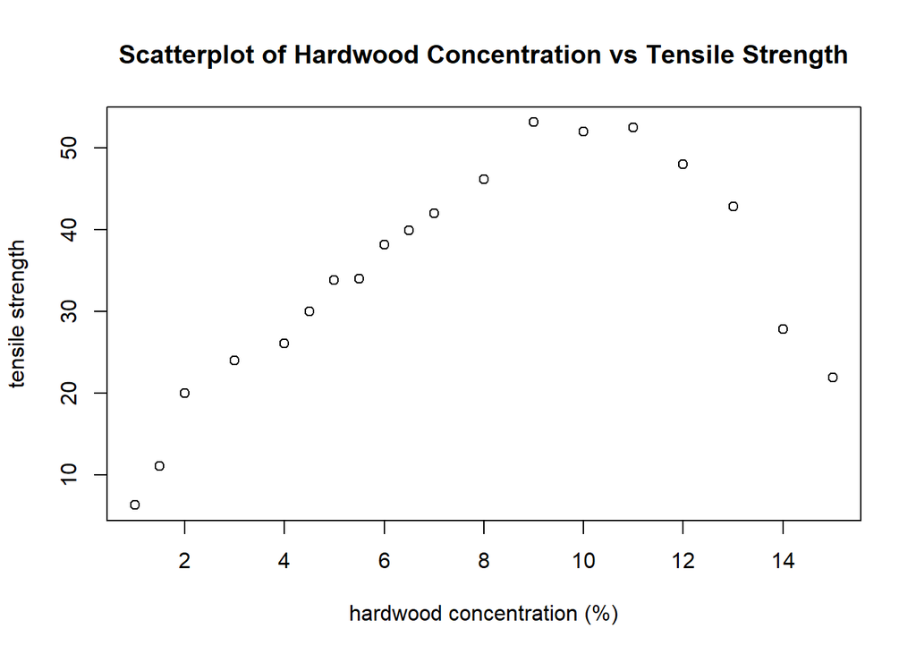

```r
plot(Concentration, Strength, main = "Scatterplot of Hardwood Concentration vs Tensile Strength",
     xlab = "hardwood concentration (%)",
     ylab = "tensile strength")
```

#### Fit a quadratic model on centered data; compare to p. 227

```r
n <- length(Strength)
x_mean <- sum(Concentration)/n
x_1 <- Concentration - x_mean
x_2 <- x_1^2

model.71 <- lm(Strength ~ x_1 + x_2)

summary(model.71)
```

Call: lm(formula = Strength ~ x_1 + x_2)

Residuals: Min 1Q Median 3Q Max -5.8503 -3.2482 -0.7267 4.1350 6.5506

Residual standard error: 4.42 on 16 degrees of freedom Multiple R-squared: 0.9085, Adjusted R-squared: 0.8971 F-statistic: 79.43 on 2 and 16 DF, p-value: 4.912e-09

```r
xtable(summary(model.71))
```

|  | Estimate | Std. Error | t value | Pr(>\|t\|) |
| --- | --- | --- | --- | --- |
| (Intercept) | 45.2949731 | 1.48287271 | 30.54542 | 1.291590e-15 |
| x_1 | 2.5463440 | 0.25383896 | 10.03134 | 2.629797e-08 |
| x_2 | -0.6345492 | 0.06178832 | -10.26973 | 1.894349e-08 |

#### Create ANOVA table (by hand and with R); compare to Table 7.2 on p. 228

```r
# create ANOVA table by hand
n <- length(Strength)
k <- 2                    # number of regressors
p <- k + 1                # number of parameters

X <- cbind(matrix(1,length(Strength),1),as.matrix(x_1),as.matrix(x_2))
y <- as.matrix(Strength)

# X'X matrix
xTx <- t(X) %*% X

# Beta Coefficients
beta_hat <- ginv(xTx,tol =  .Machine$double.eps) %*% t(X) %*% y

# eqn 3.24
SS_Reg <- t(beta_hat) %*% t(X) %*% y - (sum(y))^2/n

MS_Reg <- SS_Reg/k

# eqn 3.16
SS_Res <- t(y) %*% y - t(beta_hat) %*% t(X) %*% y

# eqn 3.17
MS_Res <- SS_Res/(n-p)

# eqn 3.24
SS_T <- t(y) %*%  y - (sum(y))^2/n

F_0 <- MS_Reg/MS_Res

# t-critical and p-value calculations
# for alpha = 0.05
alpha = 0.05

p_val_f = 1 - pf(F_0, k, n-p)

# create ANOVA table with R
xtable(anova(model.71))
```

|  | Df | Sum Sq | Mean Sq | F value | Pr(>F) |
| --- | --- | --- | --- | --- | --- |
| x_1 | 1 | 1043.4274 | 1043.42743 | 53.39985 | 1.758404e-06 |
| x_2 | 1 | 2060.8195 | 2060.81954 | 105.46729 | 1.894349e-08 |
| Residuals | 16 | 312.6383 | 19.53989 | NA | NA |

SS Regression: $3104.2469747$

SS Residual: $312.6382884$

SS Total: $3416.8852632$

Regression Degrees of Freedom: $2$

Residual Degrees of Freedom: $16$

Total Degrees of Freedom: $18$

Mean Square Regression: $1552.1234874$

Mean Square Residual: $19.539893$

$F_0 = 79.4335714$

P Value: $4.9124048\times 10^{-9}$

#### Test significance of quadratic term using Partial F-test. Use alpha = 0.01 as the significance level. Compare to p. 229

```r
# full model including the quadratic term
model.full <- lm(Strength ~ x_1 + x_2)

# reduced model excluding the quadratic term
model.reduced <- lm(Strength ~ x_1)

# anova -- comparision of reduced to full model
anova(model.reduced, model.full)
```

|  | Res.Df | RSS | Df | Sum of Sq | F | Pr(>F) |
| --- | --- | --- | --- | --- | --- | --- |
| 1 | 17 | 2373.4578 | NA | NA | NA | NA |
| 2 | 16 | 312.6383 | 1 | 2060.82 | 105.4673 | 1.894349e-08 |

```r
# F crit
alpha <- 0.01
df_SS_R <- anova(model.reduced, model.full)$'Df'[2]
df_SS_Res <- anova(model.reduced, model.full)$'Res.Df'[2]

F_crit <- qf(1-alpha,df_SS_R,df_SS_Res)
```

#### Create residuals versus fits plot

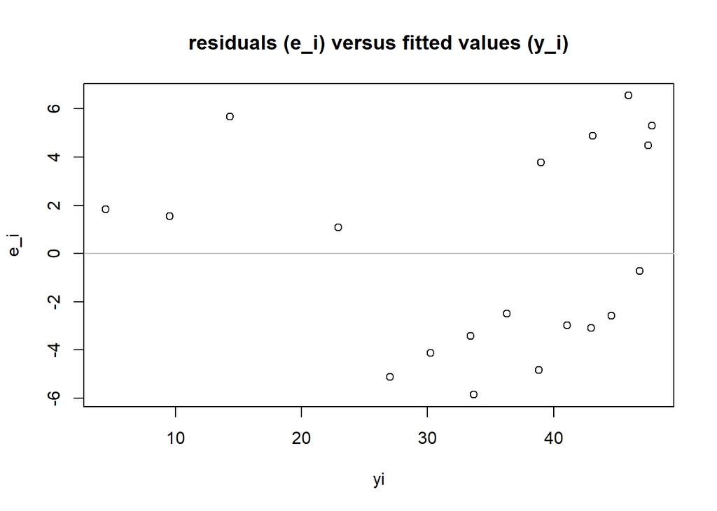

```r
plot(model.71$fitted.values, model.71$residuals, main = "residuals (e_i) versus fitted values (ŷ_i)", xlab = "ŷi", ylab = "e_i")
abline(0, 0, col = "gray")
```

This plot does not reveal any serious model inadequacy.

#### Create normal probability plot of residuals

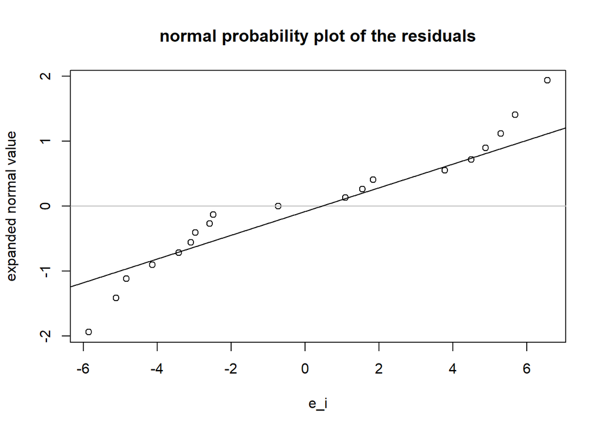

```r
# set datax = TRUE to resemble plot in book; default value is datax = FALSE
# however, y- and x-label won't change iaw datax = TRUE
qqnorm(model.71$residuals, datax = TRUE, main="normal probability plot of the residuals", ylab = "e_i", xlab = "expanded normal value")
abline(0, 0, col = "gray")
qqline(model.71$residuals, datax = TRUE)
```